# Bud segmentation analysis of mRNAs in yeast

#### Plot sec72 vs wt with replicates, mean by strain and t-test results highlighted

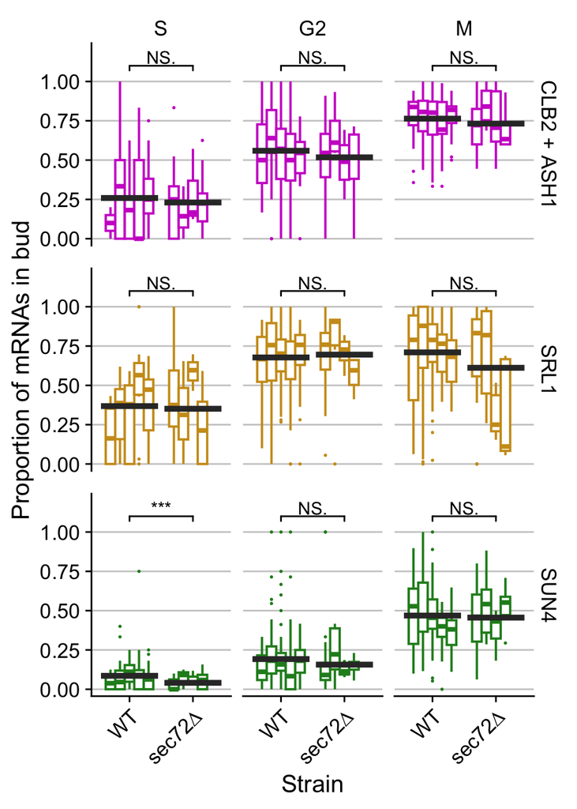

```r
ggplot(data = mrna_alldata_wphase %>%
         filter( strain_nice  %in% c("WT", "sec72∆"),
                 cell_cycle_phase %in% c("S", "G2", "M"),
                 total_RNAs > 0),
       mapping = aes(x = strain_nice,
                   y = total_RNAs_bud / total_RNAs)) +
  geom_boxplot(aes(colour = mRNA,
                   group = interaction(strain, replicate)
                   ),
               position = position_dodge(preserve = "single"),
               outlier.size = 0.3) +
  stat_summary(fun = mean,
               geom = "crossbar",
               colour = "grey20") +
  geom_signif(
    # this is for plotting significance comparisons
    # plays badly with factors, so c(1,2) instead of c("WT", "ssd1∆")
    comparisons = list(c(1,2)),
    y_position = c(1.05),
    map_signif_level = TRUE,
    test = "t.test"
  ) +
  facet_grid(mRNA ~ cell_cycle_phase,
             scales = "free_y") +
  scale_colour_mrna() +
  scale_y_continuous(limits = c(0, 1.2),
                     expand = c(0.02,0.02),
                     breaks = c(0.0, 0.25, 0.5, 0.75, 1.0)) +
  labs(y = "Proportion of mRNAs in bud",
       x = "Strain") +
  theme(panel.grid.major.y = element_line(colour = "grey80"),
        axis.text.x = element_text(angle = 45, hjust = 1),
        legend.position = "none",
        panel.spacing.y = unit(5, "mm"))
```

```r
ggsave(here::here("figure","propmrna_by_cellcycle_phase_wtsec72_statbyreplicate.pdf"),
       width = unit(5, "in"), height = unit(6, "in"),
       device=cairo_pdf)
```

# Output samples of cells by strain and cell cycle phase

Goal here is to ample at random a small number of cells from each subset that we want to highlight, so that we can spot-check the statistics against cell images and also choose cells to display in a mostly unbiased way.

```r
sample_cells_byphase <- function(df, mystrain, myphase, n = 10) {
  df %>%
    filter(mRNA == "CLB2 + ASH1", # because cell stats are repeated 3x
           strain_nice == mystrain,
           cell_cycle_phase == myphase) %>%
    slice_sample(n=n) %>%
    arrange(row_id)
}

write_sample_cells_byphase <-
  function(df, mystrain, myphase, filename, n = 10, dirstem = "output") {
    sample_cells_byphase(df = df, mystrain = mystrain, myphase = myphase, n=n) %>%
      select(row_id, uid, strain, condition, replicate, fov, image_cell_id, source_folder) %>%
      write_csv(file = here::here(dirstem, filename))
  }

# test it.
mrna_alldata_wphase %>%
  sample_cells_byphase("WT","G1")
```

```
## # A tibble: 10 × 57
##    row_id image_cell_id bbox_0 bbox_1 bbox_2 bbox_3  area eccentricity
##     <dbl>         <dbl>  <dbl>  <dbl>  <dbl>  <dbl> <dbl>        <dbl>
##  1   5389            39    641    583    703    644  2672        0.671
##  2   5416            78   1216    247   1268    306  2390        0.518
##  3   5659            10    122    607    179    665  2718        0.301
##  4   5728           168   2105   2041   2151   2101  2133        0.631
##  5  24940            52   1678    234   1731    292  2387        0.409
##  6  27958           205   1221    734   1295    794  3276        0.719
##  7  28107           119   1045   1214   1094   1285  2685        0.767
##  8  32454            52   1635    909   1686    969  2478        0.589
##  9  32616            53    855     42    908    109  2720        0.653
## 10  33180           141   1691     72   1748    128  2491        0.324
## # ℹ 49 more variables: axis_minor_length <dbl>, axis_major_length <dbl>,
## #   orientation <dbl>, perimeter <dbl>, solidity <dbl>, bbox_0_bud <dbl>,
## #   bbox_1_bud <dbl>, bbox_2_bud <dbl>, bbox_3_bud <dbl>, area_bud <dbl>,
## #   eccentricity_bud <dbl>, axis_minor_length_bud <dbl>,
## #   axis_major_length_bud <dbl>, orientation_bud <dbl>, perimeter_bud <dbl>,
## #   solidity_bud <dbl>, spots <dbl>, dense_regions <dbl>,
## #   decomposed_RNAs <dbl>, tx <dbl>, nascent_RNAs <dbl>, total_RNAs <dbl>, …
```

Spot-check non-assigned cells, in file `NA_sample20cells.csv`.

```r
# Spot-check non-assigned cells
set.seed(2026) # set seed so same pseudorandom sample each time
mrna_alldata_wphase %>%
  filter(mRNA == "CLB2 + ASH1", # because cell stats are repeated 3x
         # strain_nice == "WT",
         is.na(cell_cycle_phase)) %>%
  slice_sample(n=20) %>%
  arrange(row_id)%>%
  select(row_id, uid, strain, condition, replicate, fov, image_cell_id, source_folder) %>%
  write_csv(file = here::here("output", "NA_sample20cells.csv"))

# write_sample_cells_byphase(mrna_alldata_wphase,
#                            "WT",
#                            "G1",
#                            "WT_G1_sample16cells.csv"
#                           )
```

The next chunk gives ids for 20 cells sampled at random for each combination of

- strain (WT, ssd1∆, mpt5∆, she2∆, she3∆)
- cell cycle phase (G1, S, G2, M)

For example, file `WT_G1_sample20cells.csv` has 20 cells from WT in G1.

```r
set.seed(2026)
expand_grid(strain_nice  = c("WT", "ssd1Δ", "mpt5∆", "she2∆", "she3∆"),
            cell_cycle_phase = c("G1", "S", "G2", "M")) %>%
  rowwise() %>%
  do(write_sample_cells_byphase(df = mrna_alldata_wphase,
                                mystrain = .$strain_nice,
                                myphase = .$cell_cycle_phase,
                                filename = paste(.$strain_nice,
                                                 .$cell_cycle_phase,
                                                 "sample20cells.csv",
                                                 sep = "_"),
                                n = 20)
     )
```

```
## # A tibble: 400 × 8
## # Rowwise:
##    row_id uid       strain condition replicate fov   image_cell_id source_folder
##     <dbl> <chr>     <chr>  <chr>     <fct>     <chr>         <dbl> <chr>
##  1   5158 YET915_B… YET915 WT        BR5       01               74 ../../240909…
##  2   5658 YET915_B… YET915 WT        BR5       03                8 ../../240909…
##  3  24927 YET915_B… YET915 WT        BR3       01               36 ../../220601…
##  4  24932 YET915_B… YET915 WT        BR3       01               41 ../../220601…
##  5  24937 YET915_B… YET915 WT        BR3       01               48 ../../220601…
##  6  25074 YET915_B… YET915 WT        BR3       03               26 ../../220601…
##  7  25137 YET915_B… YET915 WT        BR3       03              103 ../../220601…
##  8  25146 YET915_B… YET915 WT        BR3       03              113 ../../220601…
##  9  25401 YET915_B… YET915 WT        BR3       04               61 ../../220601…
## 10  25422 YET915_B… YET915 WT        BR3       04               85 ../../220601…
## # ℹ 390 more rows
```